# 갑상선 질환에 영향을 미치는 요인은 어떤 것이 있을까?

# 갑상선 질환 여부를 예측하는 통계모델 구축

#### => 성별, 나이, 음주량, 흡연여부, 수면시간, BMI, 스트레스, 콜레스테롤수치를 이용해 분석 진행

```python
import numpy as np
import numpy.random as random
import scipy as sp
import scipy.stats as stats
import pandas as pd
from pandas import Series, DataFrame

# 시각화 라이브러리
import matplotlib.pyplot as plt
import matplotlib as mpl
import seaborn as sns
%matplotlib inline

import statsmodels.formula.api as smf
import statsmodels.api as sm

# 소수점 3자리까지 표시
%precision 3
```

```
'%.3f'
```

```python
#국민건강영양조사 데이터 불러오기
data10 = pd.read_csv('hn10_all.csv')
data11 = pd.read_csv('hn11_all.csv')
data12 = pd.read_csv('hn12_all.csv')
data13 = pd.read_csv('hn13_all.csv')
data14 = pd.read_csv('hn14_all.csv')
data15 = pd.read_csv('hn15_all.csv')
data16 = pd.read_csv('hn16_all.csv')
data17 = pd.read_csv('hn17_all.csv')
data18 = pd.read_csv('hn18_all.csv')
data19 = pd.read_csv('hn19_all.csv')
```

```python
#불러온 데이터 합치기
data_all = pd.concat([data10,data11,data12,data13,data14,data15,data16,data17,data18,data19])
data_all.head()
```

|  | mod_d | ID | ID_fam | year | region | town_t | apt_t | psu | sex | age | ... | BS12_47_1 | BS12_47_2 | HE_nc | HE_insulin_etc | HE_DM_HbA1c | HE_HBsAg_etc | HE_Ucrea_etc | HE_Ualb_etc | N_FOLATE | LF_SECUR_Y |
| --- | --- | --- | --- | --- | --- | --- | --- | --- | --- | --- | --- | --- | --- | --- | --- | --- | --- | --- | --- | --- | --- |
| 0 | 2019.03.06. | A308059801 | A3080598 | 2010 | 1 | 1 | 2 | A308 | 1 | 61 | ... | NaN | NaN | NaN | NaN | NaN | NaN | NaN | NaN | NaN | NaN |
| 1 | 2019.03.06. | A308059802 | A3080598 | 2010 | 1 | 1 | 2 | A308 | 2 | 54 | ... | NaN | NaN | NaN | NaN | NaN | NaN | NaN | NaN | NaN | NaN |
| 2 | 2019.03.06. | A308120201 | A3081202 | 2010 | 1 | 1 | 2 | A308 | 1 | 33 | ... | NaN | NaN | NaN | NaN | NaN | NaN | NaN | NaN | NaN | NaN |
| 3 | 2019.03.06. | A308120202 | A3081202 | 2010 | 1 | 1 | 2 | A308 | 2 | 33 | ... | NaN | NaN | NaN | NaN | NaN | NaN | NaN | NaN | NaN | NaN |
| 4 | 2019.03.06. | A308120203 | A3081202 | 2010 | 1 | 1 | 2 | A308 | 2 | 4 | ... | NaN | NaN | NaN | NaN | NaN | NaN | NaN | NaN | NaN | NaN |

5 rows × 1440 columns

```python
# 흡연자, 비흡연자를 나타내는 smoking column 생성하기

smoking_map={
    1.0: 1,
    2.0: 1,
    3.0: 0
}
# 1은 흡연자, 0은 비흡연자

data_all['smoking'] = data_all['BS1_1'].map(smoking_map)
```

```python
#음주 정도를 나타내는 drinking column 생성하기

drink = data_all[['ID','BD1_11','BD2_1']].dropna()
drink = drink[(drink['BD1_11']<7) & (drink['BD2_1']<7)]

drink['drinking'] = drink['BD1_11']*drink['BD2_1'] #불러온 데이터에서 결측치와 무응답을 제거한 후 음주횟수와 음주빈도를 곱함

drinking = drink[['ID','drinking']]
```

```python
#2010~2015의 데이터와 2016~2019의 데이터에서의 하루 평균 수면시간을 나타내는 변수명이 다르므로 기간을 나눠 따로 구해서 합쳐주기
data10_15 = pd.concat([data10,data11,data12,data13,data14,data15])
data16_19 = pd.concat([data16,data17,data18,data19], ignore_index = True )
```

```python
data10_15 = data10_15[['ID','BP8']]
data10_15 = data10_15[data10_15.BP8<25]
data10_15['sleeping'] = data10_15['BP8']
data10_15 = data10_15[['ID','sleeping']]
data10_15
```

|  | ID | sleeping |
| --- | --- | --- |
| 0 | A308059801 | 6.0 |
| 1 | A308059802 | 6.0 |
| 2 | A308120201 | 7.0 |
| 3 | A308120202 | 8.0 |
| 5 | A308199801 | 5.0 |
| ... | ... | ... |
| 7375 | P296755016 | 4.0 |
| 7376 | P296777116 | 10.0 |
| 7377 | P296781216 | 5.0 |
| 7378 | P296783215 | 6.0 |
| 7379 | P296783216 | 5.0 |

37380 rows × 2 columns

```python
#2016~2019의 데이터에선 평균 수면시간이 주중과 주말로 나뉘어있으므로 둘의 평균을 구하기
sleep = data16_19[['ID','Total_slp_wk','Total_slp_wd']].dropna()
sleep = sleep[(sleep['Total_slp_wk']<2000) & (sleep['Total_slp_wd']<2000)]

sleep['sleeping'] = (sleep['Total_slp_wk'] + sleep['Total_slp_wd']) / 120

import math

sleep_r = []
for i in sleep['sleeping']:
    a = float("%.1f" % i)
    sleep_r.append(math.ceil(a))

sleep['sleeping'] = sleep_r

sleep = sleep[['ID','sleeping']]
sleep
```

|  | ID | sleeping |
| --- | --- | --- |
| 0 | A651172801 | 8 |
| 1 | A651172802 | 8 |
| 2 | A651183001 | 7 |
| 3 | A651183002 | 7 |
| 4 | A651183003 | 7 |
| ... | ... | ... |
| 24258 | R904028501 | 9 |
| 24259 | R904028502 | 9 |
| 24260 | R904028503 | 8 |
| 24264 | R904028902 | 10 |
| 24265 | R904029201 | 8 |

19099 rows × 2 columns

```python
sleeping = pd.concat([data10_15,sleep],ignore_index=True)
sleeping
```

|  | ID | sleeping |
| --- | --- | --- |
| 0 | A308059801 | 6.0 |
| 1 | A308059802 | 6.0 |
| 2 | A308120201 | 7.0 |
| 3 | A308120202 | 8.0 |
| 4 | A308199801 | 5.0 |
| ... | ... | ... |
| 56474 | R904028501 | 9.0 |
| 56475 | R904028502 | 9.0 |
| 56476 | R904028503 | 8.0 |
| 56477 | R904028902 | 10.0 |
| 56478 | R904029201 | 8.0 |

56479 rows × 2 columns

```python
#전체 데이터에서 우리가 사용할 변수들만 불러오기
data_n = data_all.loc[:,['ID','sex','age','HE_chol','smoking','mh_stress','HE_BMI','DE2_dg']]
data_n.tail()
```

|  | ID | sex | age | HE_chol | smoking | mh_stress | HE_BMI | DE2_dg |
| --- | --- | --- | --- | --- | --- | --- | --- | --- |
| 8105 | R504381902 | 2 | 48 | 200.0 | 0.0 | 0.0 | 20.535409 | 0.0 |
| 8106 | R504393801 | 1 | 47 | 209.0 | 0.0 | 0.0 | 22.400779 | 0.0 |
| 8107 | R504393802 | 2 | 43 | 215.0 | 0.0 | 0.0 | 15.375148 | 0.0 |
| 8108 | R504393803 | 2 | 16 | 145.0 | NaN | 1.0 | 14.844970 | 8.0 |
| 8109 | R504393804 | 1 | 8 | NaN | NaN | NaN | 14.528000 | 8.0 |

```python
#이해하기 쉽게 column명 바꿔주기
data_n = data_n.rename(columns = {'HE_chol':'cholesterol','mh_stress':'stress', 'HE_BMI':'BMI', 'DE2_dg':'thyroid_D'})
data_n
```

|  | ID | sex | age | cholesterol | smoking | stress | BMI | thyroid_D |
| --- | --- | --- | --- | --- | --- | --- | --- | --- |
| 0 | A308059801 | 1 | 61 | 189.0 | 1.0 | 0.0 | 26.177198 | 8.0 |
| 1 | A308059802 | 2 | 54 | 179.0 | 0.0 | 0.0 | 22.807647 | 8.0 |
| 2 | A308120201 | 1 | 33 | 200.0 | 1.0 | 0.0 | 26.562865 | 8.0 |
| 3 | A308120202 | 2 | 33 | 236.0 | 1.0 | 1.0 | 20.863743 | 8.0 |
| 4 | A308120203 | 2 | 4 | NaN | NaN | NaN | 14.619757 | 8.0 |
| ... | ... | ... | ... | ... | ... | ... | ... | ... |
| 8105 | R504381902 | 2 | 48 | 200.0 | 0.0 | 0.0 | 20.535409 | 0.0 |
| 8106 | R504393801 | 1 | 47 | 209.0 | 0.0 | 0.0 | 22.400779 | 0.0 |
| 8107 | R504393802 | 2 | 43 | 215.0 | 0.0 | 0.0 | 15.375148 | 0.0 |
| 8108 | R504393803 | 2 | 16 | 145.0 | NaN | 1.0 | 14.844970 | 8.0 |
| 8109 | R504393804 | 1 | 8 | NaN | NaN | NaN | 14.528000 | 8.0 |

80861 rows × 8 columns

```python
#결측치 제거하기
data_n = data_n.dropna()
data_n
```

|  | ID | sex | age | cholesterol | smoking | stress | BMI | thyroid_D |
| --- | --- | --- | --- | --- | --- | --- | --- | --- |
| 0 | A308059801 | 1 | 61 | 189.0 | 1.0 | 0.0 | 26.177198 | 8.0 |
| 1 | A308059802 | 2 | 54 | 179.0 | 0.0 | 0.0 | 22.807647 | 8.0 |
| 2 | A308120201 | 1 | 33 | 200.0 | 1.0 | 0.0 | 26.562865 | 8.0 |
| 3 | A308120202 | 2 | 33 | 236.0 | 1.0 | 1.0 | 20.863743 | 8.0 |
| 5 | A308199801 | 1 | 65 | 217.0 | 1.0 | 1.0 | 19.664116 | 8.0 |
| ... | ... | ... | ... | ... | ... | ... | ... | ... |
| 8103 | R504375103 | 2 | 26 | 161.0 | 0.0 | 0.0 | 19.409690 | 0.0 |
| 8104 | R504380201 | 1 | 62 | 154.0 | 1.0 | 1.0 | 18.681380 | 0.0 |
| 8105 | R504381902 | 2 | 48 | 200.0 | 0.0 | 0.0 | 20.535409 | 0.0 |
| 8106 | R504393801 | 1 | 47 | 209.0 | 0.0 | 0.0 | 22.400779 | 0.0 |
| 8107 | R504393802 | 2 | 43 | 215.0 | 0.0 | 0.0 | 15.375148 | 0.0 |

55196 rows × 8 columns

```python
#성별 F,M으로 나타내기

sex_map={
    1.0: 'M',
    2.0: 'F'
}

data_n['sex'] = data_n['sex'].map(sex_map)
```

```python
#만들어둔 데이터와 음주관련 데이터 합치기
data = pd.merge(data_n, drinking, how='inner', on = 'ID')
data
```

|  | ID | sex | age | cholesterol | smoking | stress | BMI | thyroid_D | drinking |
| --- | --- | --- | --- | --- | --- | --- | --- | --- | --- |
| 0 | A308059801 | M | 61 | 189.0 | 1.0 | 0.0 | 26.177198 | 8.0 | 4.0 |
| 1 | A308059802 | F | 54 | 179.0 | 0.0 | 0.0 | 22.807647 | 8.0 | 2.0 |
| 2 | A308120201 | M | 33 | 200.0 | 1.0 | 0.0 | 26.562865 | 8.0 | 25.0 |
| 3 | A308120202 | F | 33 | 236.0 | 1.0 | 1.0 | 20.863743 | 8.0 | 8.0 |
| 4 | A308199801 | M | 65 | 217.0 | 1.0 | 1.0 | 19.664116 | 8.0 | 10.0 |
| ... | ... | ... | ... | ... | ... | ... | ... | ... | ... |
| 40013 | R504375101 | M | 55 | 200.0 | 1.0 | 0.0 | 24.370606 | 0.0 | 20.0 |
| 40014 | R504375102 | F | 53 | 212.0 | 0.0 | 0.0 | 23.764537 | 0.0 | 3.0 |
| 40015 | R504375103 | F | 26 | 161.0 | 0.0 | 0.0 | 19.409690 | 0.0 | 16.0 |
| 40016 | R504380201 | M | 62 | 154.0 | 1.0 | 1.0 | 18.681380 | 0.0 | 12.0 |
| 40017 | R504381902 | F | 48 | 200.0 | 0.0 | 0.0 | 20.535409 | 0.0 | 4.0 |

40018 rows × 9 columns

```python
data = pd.merge(data[data['thyroid_D']<3], sleeping, how='inner', on='ID') #갑상선 데이터에서 결측치를 제외한 것과 수면시간 데이터 합치기
data
```

|  | ID | sex | age | cholesterol | smoking | stress | BMI | thyroid_D | drinking | sleeping |
| --- | --- | --- | --- | --- | --- | --- | --- | --- | --- | --- |
| 0 | A311239802 | F | 24 | 164.0 | 1.0 | 1.0 | 17.441032 | 1.0 | 20.0 | 7.0 |
| 1 | A312139802 | F | 56 | 199.0 | 0.0 | 1.0 | 29.021472 | 1.0 | 12.0 | 6.0 |
| 2 | A314659802 | F | 21 | 182.0 | 0.0 | 0.0 | 19.027994 | 1.0 | 16.0 | 6.0 |
| 3 | A315860901 | M | 58 | 193.0 | 1.0 | 0.0 | 19.654081 | 1.0 | 10.0 | 7.0 |
| 4 | A316620904 | F | 66 | 260.0 | 0.0 | 0.0 | 23.823880 | 1.0 | 4.0 | 7.0 |
| ... | ... | ... | ... | ... | ... | ... | ... | ... | ... | ... |
| 23041 | R904028101 | M | 42 | 141.0 | 0.0 | 0.0 | 25.356937 | 0.0 | 6.0 | 8.0 |
| 23042 | R904028501 | M | 41 | 172.0 | 1.0 | 1.0 | 28.496550 | 0.0 | 20.0 | 9.0 |
| 23043 | R904028502 | F | 35 | 185.0 | 0.0 | 0.0 | 21.773149 | 0.0 | 4.0 | 9.0 |
| 23044 | R904028503 | F | 66 | 180.0 | 0.0 | 0.0 | 25.957028 | 0.0 | 3.0 | 8.0 |
| 23045 | R904029201 | M | 43 | 216.0 | 1.0 | 1.0 | 26.904906 | 0.0 | 25.0 | 8.0 |

23046 rows × 10 columns

```python
#하나의 독립변수에 의한 통계모델 구하기
null_mod = smf.glm(formula = "thyroid_D ~ 1", data = data, family=sm.families.Binomial()).fit()
mo_sex = smf.glm(formula = "thyroid_D ~ sex", data = data, family=sm.families.Binomial()).fit()
mo_age = smf.glm(formula = "thyroid_D ~ age", data = data, family=sm.families.Binomial()).fit()
mo_cholesterol = smf.glm(formula = "thyroid_D ~ cholesterol", data = data, family=sm.families.Binomial()).fit()
mo_smoking = smf.glm(formula = "thyroid_D ~ smoking", data = data, family=sm.families.Binomial()).fit()
mo_stress = smf.glm(formula = "thyroid_D ~ stress", data = data, family=sm.families.Binomial()).fit()
mo_BMI = smf.glm(formula = "thyroid_D ~ BMI", data = data, family=sm.families.Binomial()).fit()
mo_drinking = smf.glm(formula = "thyroid_D ~ drinking", data = data, family=sm.families.Binomial()).fit()
mo_sleeping = smf.glm(formula = "thyroid_D ~ sleeping", data = data, family=sm.families.Binomial()).fit()
```

```python
#각 통계모델의 AIC값 구하기
aic_mod = []
variable = [mo_sex,mo_age,mo_cholesterol,mo_smoking,mo_stress,mo_BMI,mo_drinking,mo_sleeping]
for i in range(6):
    a = '변수가 %s인 모델 : %f' % (data.columns[i+1],variable[i].aic.round(3))
    aic_mod.append(a)
for j in range(1,3):
    b = '변수가 %s인 모델 : %f' % (data.columns[-j],variable[-j].aic.round(3))
    aic_mod.append(b)

print('null 모델 : %f'%null_mod.aic)
aic_mod
```

```
null 모델 : 9161.973050
```

```
['변수가 sex인 모델 : 8643.867000',
 '변수가 age인 모델 : 9116.493000',
 '변수가 cholesterol인 모델 : 9162.944000',
 '변수가 smoking인 모델 : 8951.448000',
 '변수가 stress인 모델 : 9162.323000',
 '변수가 BMI인 모델 : 9160.962000',
 '변수가 sleeping인 모델 : 9139.998000',
 '변수가 drinking인 모델 : 8916.056000']
```

## AIC 낮은 순: sex drink smoking age sleeping BMI null stress cholesterol

```python
#위에서 구한 AIC값이 낮은 순으로 변수를 하나씩 더해가며 통계모델 구하기
mo1 = smf.glm(formula = "thyroid_D ~ sex", data = data, family=sm.families.Binomial()).fit()
mo2 = smf.glm(formula = "thyroid_D ~ sex+drinking", data = data, family=sm.families.Binomial()).fit()
mo3 = smf.glm(formula = "thyroid_D ~ sex+drinking+smoking", data = data, family=sm.families.Binomial()).fit()
mo4 = smf.glm(formula = "thyroid_D ~ sex+drinking+smoking+age", data = data, family=sm.families.Binomial()).fit()
mo5 = smf.glm(formula = "thyroid_D ~ sex+drinking+smoking+age+sleeping", data = data, family=sm.families.Binomial()).fit()
mo6 = smf.glm(formula = "thyroid_D ~ sex+drinking+smoking+age+sleeping+BMI", data = data, family=sm.families.Binomial()).fit()
mo7 = smf.glm(formula = "thyroid_D ~ sex+drinking+smoking+age+sleeping+BMI+stress", data = data, family=sm.families.Binomial()).fit()
mo8 = smf.glm(formula = "thyroid_D ~ sex+drinking+smoking+age+sleeping+BMI+stress+cholesterol", data = data, family=sm.families.Binomial()).fit()
```

```python
#각 통계모델의 AIC값 구하기
mo1.aic, mo2.aic, mo3.aic, mo4.aic, mo5.aic, mo6.aic, mo7.aic,mo8.aic
```

```
(8643.867129262551,
 8600.276822153794,
 8597.368557780337,
 8547.27101122185,
 8534.36425928483,
 8536.090436013514,
 8536.509387605924,
 8531.853560786485)
```

확실히 다들 null_model 보다는 AIC가 낮다

```python
#AIC가 올라가다 마지막에 갑자기 낮아져 마지막 모델을 살펴봄
mo8.summary()
```

Generalized Linear Model Regression Results

| Dep. Variable: | thyroid_D | No. Observations: | 23046 |
| --- | --- | --- | --- |
| Model: | GLM | Df Residuals: | 23037 |
| Model Family: | Binomial | Df Model: | 8 |
| Link Function: | logit | Scale: | 1.0000 |
| Method: | IRLS | Log-Likelihood: | -4256.9 |
| Date: | Tue, 08 Jun 2021 | Deviance: | 8513.9 |
| Time: | 14:04:43 | Pearson chi2: | 2.28e+04 |
| No. Iterations: | 7 |  |  |
| Covariance Type: | nonrobust |  |  |

|  | coef | std err | z | P>\|z\| | [0.025 | 0.975] |
| --- | --- | --- | --- | --- | --- | --- |
| Intercept | -2.1365 | 0.317 | -6.738 | 0.000 | -2.758 | -1.515 |
| sex[T.M] | -1.5689 | 0.103 | -15.272 | 0.000 | -1.770 | -1.368 |
| drinking | -0.0293 | 0.006 | -4.993 | 0.000 | -0.041 | -0.018 |
| smoking | 0.1889 | 0.092 | 2.051 | 0.040 | 0.008 | 0.369 |
| age | 0.0141 | 0.002 | 6.564 | 0.000 | 0.010 | 0.018 |
| sleeping | -0.0813 | 0.022 | -3.690 | 0.000 | -0.124 | -0.038 |
| BMI | 0.0069 | 0.009 | 0.763 | 0.446 | -0.011 | 0.025 |
| stress | 0.0869 | 0.070 | 1.247 | 0.212 | -0.050 | 0.223 |
| cholesterol | -0.0022 | 0.001 | -2.568 | 0.010 | -0.004 | -0.001 |

```python
#위의 모델에서 유의하지 않은 값을 제거했더니 더 낮은 AIC를 갖는 모델이 생성됨
model = smf.glm(formula = "thyroid_D ~ sex+drinking+smoking+age+sleeping+cholesterol", data = data, family=sm.families.Binomial()).fit()
model.aic
```

```
8530.008996034425
```

```python
#모든 변수가 유의한 값을 가지므로 이 모델을 최종모델로 채택함
model.summary()
```

Generalized Linear Model Regression Results

| Dep. Variable: | thyroid_D | No. Observations: | 23046 |
| --- | --- | --- | --- |
| Model: | GLM | Df Residuals: | 23039 |
| Model Family: | Binomial | Df Model: | 6 |
| Link Function: | logit | Scale: | 1.0000 |
| Method: | IRLS | Log-Likelihood: | -4258.0 |
| Date: | Tue, 08 Jun 2021 | Deviance: | 8516.0 |
| Time: | 14:04:44 | Pearson chi2: | 2.28e+04 |
| No. Iterations: | 7 |  |  |
| Covariance Type: | nonrobust |  |  |

|  | coef | std err | z | P>\|z\| | [0.025 | 0.975] |
| --- | --- | --- | --- | --- | --- | --- |
| Intercept | -1.9460 | 0.258 | -7.539 | 0.000 | -2.452 | -1.440 |
| sex[T.M] | -1.5771 | 0.102 | -15.414 | 0.000 | -1.778 | -1.377 |
| drinking | -0.0287 | 0.006 | -4.904 | 0.000 | -0.040 | -0.017 |
| smoking | 0.1978 | 0.092 | 2.154 | 0.031 | 0.018 | 0.378 |
| age | 0.0141 | 0.002 | 6.735 | 0.000 | 0.010 | 0.018 |
| sleeping | -0.0840 | 0.022 | -3.823 | 0.000 | -0.127 | -0.041 |
| cholesterol | -0.0021 | 0.001 | -2.509 | 0.012 | -0.004 | -0.000 |

```python
#갑상선 질환에 가장 큰 영향을 끼치는 요인이 성별이므로 데이터에서 각 성별의 수가 비슷한지 살펴봄
len(data[data.sex=='F']),len(data[data.sex=='M'])
```

```
(11735, 11311)
```

# 최종모델에서의 가중치(coef)값이 우리의 예상과는 달라 하나씩 각각 살펴보았다.

## 갑상선 질환에 걸리는 사람수 자체가 많이 없어서 증가든 감소든 0에 가까운 그래프가 나온 것으로 추측된다.

### 나이가 많을수록 갑상선 질환에 많이 걸린다.

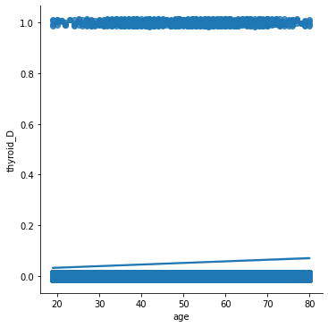

```python
sns.lmplot(x = "age", y = 'thyroid_D', data = data, x_jitter = 0.005, y_jitter = 0.015)
```

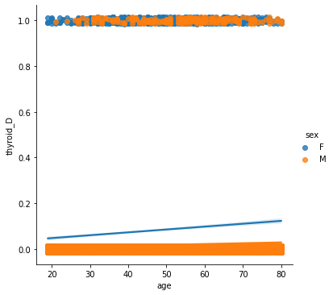

```python
sns.lmplot(x = "age", y = 'thyroid_D', data = data, hue = 'sex', x_jitter = 0.005, y_jitter = 0.015)
```

### 음주량이 많을수록 갑상선 질환에 적게 걸린다.

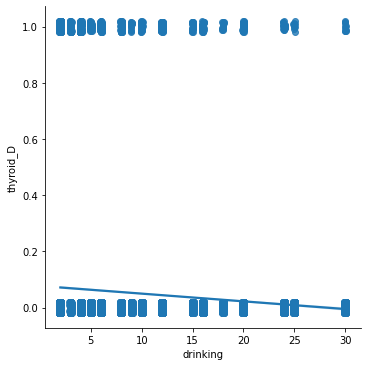

```python
sns.lmplot(x = "drinking", y = 'thyroid_D', data = data, x_jitter = 0.1, y_jitter = 0.02)
```

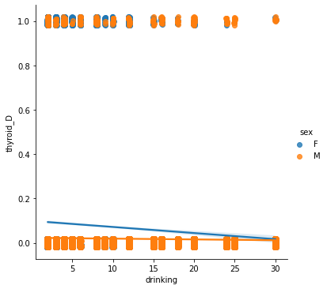

```python
sns.lmplot(x = "drinking", y = 'thyroid_D', data = data, hue='sex', x_jitter = 0.1, y_jitter = 0.02)
```

### 담배를 많이 필수록 갑상선 질환에 적게 걸린다.

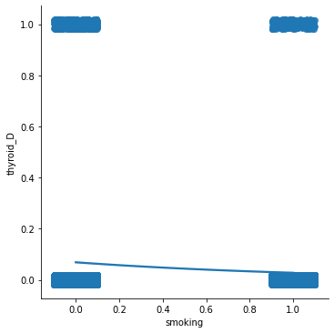

```python
#갑상선 질환 피하자고 담배 많이 걸리다가 다른 질환 걸릴 필요는 없잖아유^^
sns.lmplot(x = 'smoking', y = 'thyroid_D', data = data, logistic = True,  x_jitter = 0.1, y_jitter = 0.02)
```

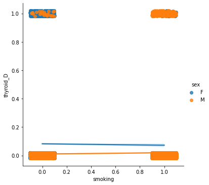

```python
sns.lmplot(x = 'smoking', y = 'thyroid_D', data = data, logistic = True, hue='sex', x_jitter = 0.1, y_jitter = 0.02)
```

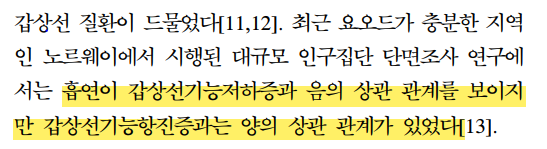

,

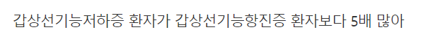

### 잠을 적게 잘수록 갑상선 질환에 많이 걸린다.

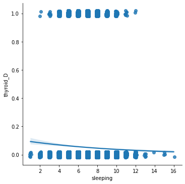

```python
sns.lmplot(x = 'sleeping', y = 'thyroid_D', data = data, logistic = True, x_jitter = 0.1, y_jitter = 0.02)
```

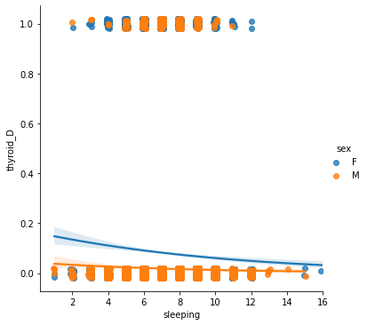

```python
sns.lmplot(x = 'sleeping', y = 'thyroid_D', data = data, logistic = True, hue='sex', x_jitter = 0.1, y_jitter = 0.02)
```

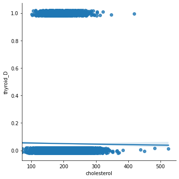

```python
sns.lmplot(x = 'cholesterol', y = 'thyroid_D', data = data, logistic = True, x_jitter = 0.1, y_jitter = 0.02)
```

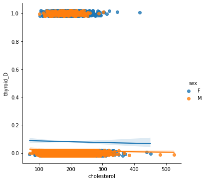

```python
sns.lmplot(x = 'cholesterol', y = 'thyroid_D', data = data, logistic = True, hue='sex', x_jitter = 0.1, y_jitter = 0.02)
```

## 여성이고, 나이가 많고, 술을 적게 마시고 , 담배를 적게 피고, 잠을 적게 자고, 콜레스테롤수치가 낮을 수록 갑상선 질환에 많이 걸린다.

# 위에서 만든 통계모델이 얼마나 예측을 잘 하는지 측정해보았다.

```python
p = model.predict()

#갑상선 질환에 걸릴 확률이 0.5이상이면 갑상선 질환으로, 그렇지 않으면 갑상선 질환이 아닌 것으로 기록함
data['predicted_thy'] = [1.0 if x >= 0.5 else 0.0 for x in p]
#예측정확도 구하기
len(data[data['thyroid_D'] == data['predicted_thy']])/len(data)
```

```
0.950
```

# 95%?????

## 단일 변수를 이용해 예측해도 계속 95%가 나왔다..

```python
#실제로 갑상선 질환에 걸린 사람과 걸리지 않은 사람의 수를 비교함
len(data[data['thyroid_D']==1.0]),len(data[data['thyroid_D']==0.0])
```

```
(1154, 21892)
```

```python
#갑상선 질환에 걸릴 것이라고 예측되는 사람과 그렇지 않은 사람의 수를 비교함
len(data[data['predicted_thy']==1.0]),len(data[data['predicted_thy']==0.0])
```

```
(0, 23046)
```

```python
len(data)
```

```
23046
```

## 갑상선 질환에 걸린 사람의 수와 걸리지 않은 사람의 수의 차이가 커서 통계모델이 어떤 조건이든 갑상선 질환에 걸리지 않는다고 예측을 해버렸고, 이때문에 해당 데이터의 모두가 갑상선 질환에 걸리지 않는다고 예측을 해도 예측정확도가 95%나 나온다.

# ==>갑상선 질환에 걸린사람의 수와 걸리지 않은 사람의 수를 동일하게 맞춰 다시 갑상선 질환에 걸릴 확률을 예측해보았다.

```python
#갑상선 질환에 걸린 사람의 수와 걸리지 않은 사람의 비율 비교하기
len(data[data['thyroid_D']==0.0]) / len(data[data['thyroid_D']==1.0])
```

```
18.971
```

```python
#갑상선 질환에 걸린 사람의 데이터만 추출하기
thyroid_D_1 = data[data['thyroid_D']==1.0]
```

```python
#갑상선 질환에 걸린 사람의 데이터를 18배로 늘리고 이를 원래의 데이터와 합치기
#(결론적으로 갑상선 질환에 걸린 사람의 데이터가 19배가 돼 갑상선 질환에 걸리지 않은 사람의 데이터와 수가 비슷해짐)
copy_n = []
for i in range(0,18):
    copy_n.append(thyroid_D_1)

data_copy_n = pd.concat(copy_n)
data_copy = pd.concat([data, data_copy_n])

data_copy
```

|  | ID | sex | age | cholesterol | smoking | stress | BMI | thyroid_D | drinking | sleeping | predicted_thy |
| --- | --- | --- | --- | --- | --- | --- | --- | --- | --- | --- | --- |
| 0 | A311239802 | F | 24 | 164.0 | 1.0 | 1.0 | 17.441032 | 1.0 | 20.0 | 7.0 | 0.0 |
| 1 | A312139802 | F | 56 | 199.0 | 0.0 | 1.0 | 29.021472 | 1.0 | 12.0 | 6.0 | 0.0 |
| 2 | A314659802 | F | 21 | 182.0 | 0.0 | 0.0 | 19.027994 | 1.0 | 16.0 | 6.0 | 0.0 |
| 3 | A315860901 | M | 58 | 193.0 | 1.0 | 0.0 | 19.654081 | 1.0 | 10.0 | 7.0 | 0.0 |
| 4 | A316620904 | F | 66 | 260.0 | 0.0 | 0.0 | 23.823880 | 1.0 | 4.0 | 7.0 | 0.0 |
| ... | ... | ... | ... | ... | ... | ... | ... | ... | ... | ... | ... |
| 22825 | O908029001 | M | 45 | 218.0 | 1.0 | 0.0 | 22.001291 | 1.0 | 4.0 | 7.0 | NaN |
| 22831 | O908033003 | F | 35 | 114.0 | 1.0 | 1.0 | 24.218312 | 1.0 | 4.0 | 5.0 | NaN |
| 22869 | O910032902 | F | 68 | 144.0 | 0.0 | 0.0 | 27.167657 | 1.0 | 2.0 | 6.0 | NaN |
| 22908 | P901027901 | M | 63 | 197.0 | 1.0 | 0.0 | 26.400849 | 1.0 | 2.0 | 10.0 | NaN |
| 22971 | P904033501 | F | 42 | 166.0 | 0.0 | 0.0 | 19.471979 | 1.0 | 3.0 | 8.0 | NaN |

43818 rows × 11 columns

```python
#수정한 데이터를 이용해 통계모델 만들기
nn = smf.glm(formula = "thyroid_D ~ sex+drinking+smoking+age+sleeping+stress+BMI+cholesterol", data = data_copy, family=sm.families.Binomial()).fit()
```

```python
nn.summary()
```

Generalized Linear Model Regression Results

| Dep. Variable: | thyroid_D | No. Observations: | 43818 |
| --- | --- | --- | --- |
| Model: | GLM | Df Residuals: | 43809 |
| Model Family: | Binomial | Df Model: | 8 |
| Link Function: | logit | Scale: | 1.0000 |
| Method: | IRLS | Log-Likelihood: | -26980. |
| Date: | Tue, 08 Jun 2021 | Deviance: | 53960. |
| Time: | 14:17:25 | Pearson chi2: | 4.38e+04 |
| No. Iterations: | 4 |  |  |
| Covariance Type: | nonrobust |  |  |

|  | coef | std err | z | P>\|z\| | [0.025 | 0.975] |
| --- | --- | --- | --- | --- | --- | --- |
| Intercept | 0.6963 | 0.110 | 6.352 | 0.000 | 0.481 | 0.911 |
| sex[T.M] | -1.6422 | 0.032 | -50.785 | 0.000 | -1.706 | -1.579 |
| drinking | -0.0260 | 0.002 | -14.670 | 0.000 | -0.029 | -0.023 |
| smoking | 0.2467 | 0.031 | 7.873 | 0.000 | 0.185 | 0.308 |
| age | 0.0179 | 0.001 | 23.164 | 0.000 | 0.016 | 0.019 |
| sleeping | -0.0853 | 0.008 | -11.201 | 0.000 | -0.100 | -0.070 |
| stress | 0.0947 | 0.024 | 3.983 | 0.000 | 0.048 | 0.141 |
| BMI | 0.0041 | 0.003 | 1.267 | 0.205 | -0.002 | 0.010 |
| cholesterol | -0.0022 | 0.000 | -7.721 | 0.000 | -0.003 | -0.002 |

```python
#유의하지 않은 p값을 가지는 BMI를 제거한 후 다시 통계모델 만들기
nn2 = smf.glm(formula = "thyroid_D ~ sex+drinking+smoking+age+sleeping+stress+cholesterol", data = data_copy, family=sm.families.Binomial()).fit()
```

```python
#모두 유의한 p값을 가지므로 nn2를 최종 모델로 확정함
nn2.summary()
```

Generalized Linear Model Regression Results

| Dep. Variable: | thyroid_D | No. Observations: | 43818 |
| --- | --- | --- | --- |
| Model: | GLM | Df Residuals: | 43810 |
| Model Family: | Binomial | Df Model: | 7 |
| Link Function: | logit | Scale: | 1.0000 |
| Method: | IRLS | Log-Likelihood: | -26981. |
| Date: | Tue, 08 Jun 2021 | Deviance: | 53961. |
| Time: | 14:17:26 | Pearson chi2: | 4.38e+04 |
| No. Iterations: | 4 |  |  |
| Covariance Type: | nonrobust |  |  |

|  | coef | std err | z | P>\|z\| | [0.025 | 0.975] |
| --- | --- | --- | --- | --- | --- | --- |
| Intercept | 0.7756 | 0.090 | 8.620 | 0.000 | 0.599 | 0.952 |
| sex[T.M] | -1.6393 | 0.032 | -50.821 | 0.000 | -1.703 | -1.576 |
| drinking | -0.0258 | 0.002 | -14.616 | 0.000 | -0.029 | -0.022 |
| smoking | 0.2455 | 0.031 | 7.839 | 0.000 | 0.184 | 0.307 |
| age | 0.0180 | 0.001 | 23.664 | 0.000 | 0.017 | 0.020 |
| sleeping | -0.0856 | 0.008 | -11.251 | 0.000 | -0.101 | -0.071 |
| stress | 0.0962 | 0.024 | 4.051 | 0.000 | 0.050 | 0.143 |
| cholesterol | -0.0022 | 0.000 | -7.622 | 0.000 | -0.003 | -0.002 |

```python
q = nn2.predict(data_copy)

#갑상선 질환에 걸릴 확률이 0.5이상이면 갑상선 질환으로, 그렇지 않으면 갑상선 질환이 아닌 것으로 기록함
data_copy['predicted_thy'] = [1.0 if x >= 0.5 else 0.0 for x in q]
#예측정확도 구하기
len(data_copy[data_copy['thyroid_D'] == data_copy['predicted_thy']]) / len(data_copy)
```

```
0.676
```

## 68%

# input 함수를 사용해 직접 변수들을 입력받아 갑상선 질환에 걸릴 확률을 예측하였다.

```python
성별 = input('성별(F,M): ')
나이 = input('나이: ')
음주빈도 = input('''음주빈도(일)
                   1. 최근 1년간 전혀 마시지 않았다
                   2. 월1회미만
                   3. 월1회정도
                   4. 월2-4회
                   5. 주2-3회정도
                   6. 주4회이상
                    :''')
음주량 = input('''1회 음주량
                1. 1-2잔
                2. 3-4잔
                3. 5-6잔
                4. 7-9잔
                5. 10잔 이상
                 :''')
흡연여부 = input('흡연여부(흡연시 1, 금연시 0): ')
콜레스테롤 = input('콜레스테롤수치: ')
수면시간 = input('하루 평균 수면시간: ')

스트레스 = input('''평소 스트레스 인지정도
                  0. 적게 느낌
                  1. 많이 느낌
                   : ''')
```

```
성별(F,M): F
나이: 55
음주빈도(일)
                   1. 최근 1년간 전혀 마시지 않았다
                   2. 월1회미만
                   3. 월1회정도
                   4. 월2-4회
                   5. 주2-3회정도
                   6. 주4회이상
                    :3
1회 음주량
                1. 1-2잔
                2. 3-4잔
                3. 5-6잔
                4. 7-9잔
                5. 10잔 이상
                 :3
흡연여부(흡연시 1, 금연시 0): 1
콜레스테롤수치: 250
하루 평균 수면시간: 7
평소 스트레스 인지정도
                  0. 적게 느낌
                  1. 많이 느낌
                   : 1
```

## 첫번째 모델의 경우(예측정확도 95%)

갑상선 질환의 유병률을 고려한 처음 모델을 사용하는 것이 맞다고 생각해 첫번째 모델을 이용해 예측해보았다.

```python
#입력받은 요인을 이용해 갑상선 질환에 걸릴 확률 예측하기
predict = model.predict(pd.DataFrame({'sex':[성별],
                                      'age':[int(나이)],
                                      'drinking':[float(음주빈도)*float(음주량)],
                                      'smoking':[float(흡연여부)],
                                      'sleeping':[float(수면시간)],
                                      'cholesterol':[float(콜레스테롤)]}))
str(predict[0])[:5]
```

```
'0.086'
```

```python
#소수점 둘째자리까지 반올림하기
if int(str(predict[0])[0]) == 1:
    predict = 100
elif int(str(predict[0])[4]) <= 4:
    predict = int(str(predict[0])[2:4])
else:
    predict = int(str(predict[0])[2:4])+1

print('당신이 갑상선 질환에 걸릴 확률은', str(predict)+'%','입니다.')
```

```
당신이 갑상선 질환에 걸릴 확률은 9% 입니다.
```

# 출처

https://e-enm.org/upload/pdf/jkes-23-123.pdf (흡연이 갑상선 질환에 미치는 영향) \ https://www.akomnews.com/bbs/board.php?bo_table=news&wr_id=15326 (갑상선기능저하증 환자수와 갑상선기능항진증 환자수의 비율)\ http://www.mkhealth.co.kr/news/articleView.html?idxno=46326 (음주와 갑상선암의 음의 상관관계)